# 2.3 단어빈도 시각화 Plotting

> 목적 : 최빈 단어 수 dataframe을 사용해서 빈도수에 대한 시각화를 수행합니다.

> 작업 :  
> => 빈도테이블을 import 한 후에 plotting을 위한 dtype에 맞게 변형시켜줍니다.  
> => 필요에 맞게 라인plot과, wordcloud를 출력합니다.

#### * 필요 패키지 import

```python
import nltk

from konlpy.tag import Okt
okt = Okt()

from wordcloud import WordCloud, STOPWORDS
import pandas as pd
import numpy as np
from PIL import Image

from wordcloud import ImageColorGenerator
```

```python
import matplotlib
import matplotlib.pyplot as plt
import platform

# 한글 폰트 호환
path = "c:/Windows/Fonts/malgun.ttf"
from matplotlib import font_manager, rc
if platform.system() == 'Darwin':
    rc('font', family='AppleGothic')
elif platform.system() == 'Windows':
    font_name = font_manager.FontProperties(fname=path).get_name()
    font = {'weight' : 'bold','size': 22}
    rc('font', family=font_name, **font)
else:
    print('Unknown system')

%matplotlib inline
```

```python
# 그림 자동 저장 코드
from matplotlib import pylab
from matplotlib import pyplot
# pylab.show = lambda: pylab.savefig('some_filename.png')
```

#### * 리뷰데이터 import

```python
from glob import glob
```

#### 공천 2016 빈도 분석 분류

2.1 NLP) 작업을 하면서 불용어 Stopwords를 1차적으로 걸렀습니다.  
이때 걸러낸 단어들은 형태소(의미를 갖는 최소 단위)이지만, 사실상 의미가 없거나('들','이','하'..), 의미가 있지만 insight를 얻기위한 분석 측면에서는 도움이 안되는 형태소('때문','웃기','결국'...) 로써 처음부터 걸러주어야 하는 형태소들을 선별해주었습니다.

하지만 불용어 제거가 된 빈도 테이블을 뽑아도 시각화 단계에서는 다시 '보다 효율적이고 직관적인 시각화 구현'을 위해서 '분명한 의미가 있지만 시각화에는 누락하길 원하는' 단어들이 다시 나올 수 있습니다.

이런 단어들을 밑에 'del_words'리스트에 추가 함으로써 시각화에서는 배제하는 방법을 사용할 수 있습니다.

중복되는 단어들이 들어갈 수 있습니다. 중복되는 단어들이 연산에 속도를 증가시키거나 에러를 초래하는 것을 방지하기 위해 .unique()를 사용하고 싶은데, 리스트는 .unique()메소드가 없습니다. 그래서 저는 pandas.Series(리스트)로 만들고 series.unique()를 한 후에 다시 ,tolist()를 통해 리스트로 되돌리는 방법을 썼습니다.

*** + 추가 ) set(list)를 하면 자동으로 해결이 됩니다!!!  
집합(set)은 중복 객체를 용남하지 않기 때문에 리스트를 그대로 집합하고 다시 리스트로 바꾸면 자동으로 unique()가 됩니다!

```python
del_words = pd.Series(['늘다','먹다','보다','알다','박다','지금','두다',
'주다','가지','밉다','당원','자다','늙다','삭제',
'행위','일이','무엇','모두','비속어','이렇게',
'어떻다','지나다','해주다','바라다','빠뜨리다',
'후련하다','기다리다',
'보이','주다','자다','지금','좋다',
'알다','먹다','오다','리다','모두',
'탈락','갈이','서다','모르다',# < 2016 공천 del_words
'사람','내년','정말','모두','지금','무슨',
'내년','오다','먹다','보여','우리','정말',
'자리','인간','이기','자다','죽다','좋다',
'알다','주다','내다','어떻다','모르다','바라다',
'지금','알다','모르다',
'자다','먹다','주다','보이','무슨','정말','오다',
'리다','내다','죽다','나가다','다시','크다','자신',
'모든','자리','야하다','생기','너희','지키다','아직도'# < 2019 공천 del_words
'혜원','사실','출신','정신','정말','역시','세상',
'머리','정도','누가','보이','우리','인간','사람',
'지금','무슨','이상','이유','모두','보고','정도',
'오다','자다','알다','내다','좋다','먹다','추다',
'나가다','당하니','그런데','그러나','그래서',
'모르다','어떻다','해보다',
'지금','모르다','알다','먹다','좋다','자다','보이','무슨',
'주다','리다','오다','정말','내다','가지','자신','싶다',
'돼다','늘리다','그냥','일이','막다','김연','모든','야하다',
'모습','해보다','바로','이상','한번','놓다','누가','여자',
'아직도','알바','해주다','ㅅㅔㅋ','뎃글','이렇게','아이디',
'konstar','신고','겁니다','누르다','수가','세'# < 2019 20대 국회 del_words
                      ])


del_words = del_words.unique().tolist()
```

- 또 모든 키워드 (즉, '20대 국회'에서도 '공천'에서도)모두 걸러내고 싶은 단어들은 위에 del_words에 넣고,  
  '20대 국회'에는 특정단어를 제외하고, '공천'에서는 또 다른 특정단어를 제외하고 싶은 경우가 있을 수 있습니다.  
  => 이 경우 밑에 ( 예: More_del_words = ['식물']) 에서 지정하면 빈도 시각화에서 특정 단어 (여기서는 '식물')를 제외하고 출력하게 됩니다.

```
최빈단어 수:  103
필터링 대상 단어 수:  96
 필터링 된 최빈단어 수:  76
```

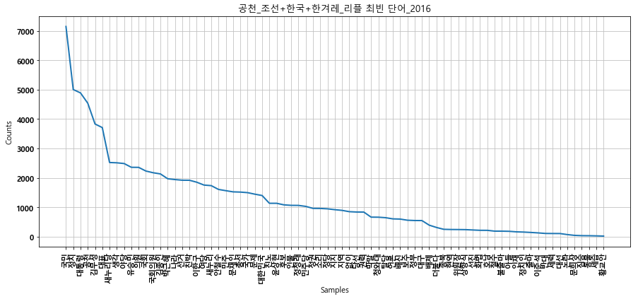

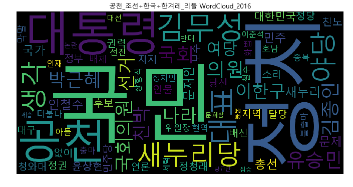

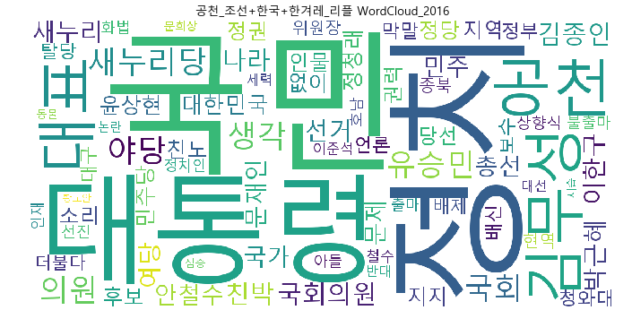

```python
# !식물
Target_keyword = '공천'
this_month = '2016'
# plot안에 제목으로 들어갈 title 변수 지정
title_lc = Target_keyword + '_조선+한국+한겨레_리플 최빈 단어_'+this_month
title_wc = Target_keyword + '_조선+한국+한겨레_리플 WordCloud_'+this_month
# 그림들을 폴더로 자동으로 export 시킬때 directory 경로 및 파일이름
fig_name_lc = '../'+Target_keyword+'_라인_'+this_month
fig_name_wwc = '../'+Target_keyword+'_워드클라우드w_'+this_month
fig_name_bwc = '../'+Target_keyword+'_워드클라우드b_'+this_month

# 통합된 빈도 xlsx파일을 불러옵니다.
file_name = '../KBS시사/DaumPoli/new_freq/공천_2016_new.xlsx'
freq_df = pd.read_excel(file_name)

# 제거해줄 단어 필터링
print('최빈단어 수: ',len(freq_df))

# 전체적으로 반영될 del_words + 해당 기간에만 반영할 추가 del_words
current_del_words = del_words.copy()
More_del_words = ['식물']
current_del_words.extend(More_del_words)
print('필터링 대상 단어 수: ',len(current_del_words))

del_index = [i for i in range(len(freq_df)) if freq_df['words'][i] in current_del_words]
freq_df.drop(del_index, inplace = True)
freq_df.reset_index(inplace = True, drop = True)
print(' 필터링 된 최빈단어 수: ',len(freq_df))

# 라인차트에 넣을 단어 corpus 형태로 복원!!
corpus = []
for i in range(len(freq_df)):
    corpus.extend([str(freq_df['words'][i])]*freq_df['freq'][i])
whole_tokens_text = nltk.Text(corpus)

#     # 워드클라우드에 넣어줄 인스턴스
#     count_list = freq_df.values.tolist()
#     freq_dict = dict(count_list)

### 라인 차트에서는 최빈출 : 50개만!
matplotlib.rcParams.update({'font.size': 11,'font.weight' : 'bold'})
pylab.show = lambda: pylab.savefig(fig_name_lc+'.png',dpi=400)
plt.figure(figsize=(15,6))
plt.title(title_lc)
whole_tokens_text.plot()
plt.show()


### 빈도 워드클라우드!
# 워드클라우드는 200개 단어로 수행!
wordcloud = WordCloud(
    font_path="c:/Windows/Fonts/malgun.ttf",
    relative_scaling = 0.2,
    #background_color = 'white',
    width = 1200, height = 600
).generate_from_frequencies(dict(whole_tokens_text.vocab().most_common(200)))

plt.figure(figsize=(12,6))
plt.title(title_wc)
plt.imshow(wordcloud)
plt.axis("off")
pyplot.savefig(fig_name_bwc+'.png', dpi=400)
plt.show()

wordcloud = WordCloud(
    font_path="c:/Windows/Fonts/malgun.ttf",
    relative_scaling = 0.2,
    background_color = 'white',
    width = 1200, height = 600
).generate_from_frequencies(dict(whole_tokens_text.vocab().most_common(200)))

plt.figure(figsize=(12,6))
plt.title(title_wc)
plt.imshow(wordcloud)
plt.axis("off")
pyplot.savefig(fig_name_wwc+'.png', dpi=400)
plt.show()
```

## 동일한 방법으로, 다른 키워드들에도 적용해보겠습니다!

#### 공천 2019 빈도 분석 분류

```
최빈단어 수:  124
필터링 대상 단어 수:  96
 필터링 된 최빈단어 수:  87
```

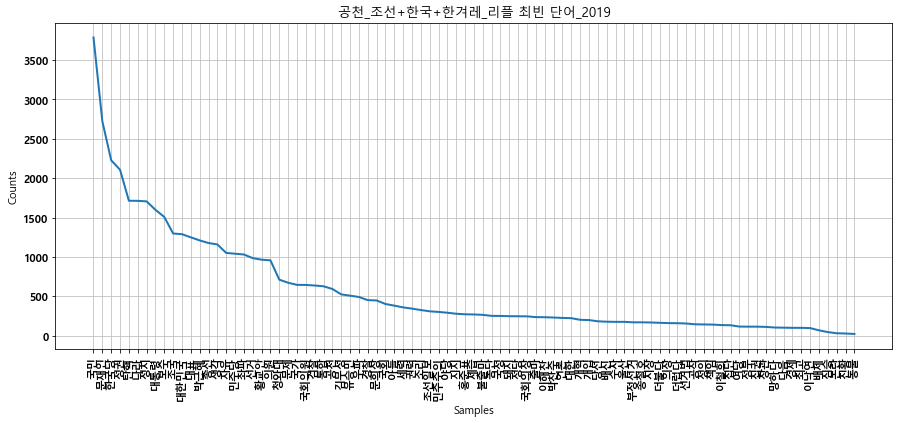

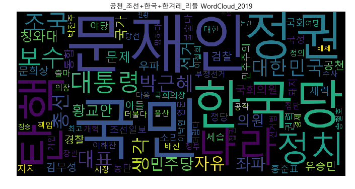

[figure not shown]

```python
# ! 동물

this_month = '2019'
title_lc = '공천_조선+한국+한겨레_리플 최빈 단어_'+this_month
title_wc = '공천_조선+한국+한겨레_리플 WordCloud_'+this_month
fig_name_lc = '../KBS시사/시각화그림/공천_라인_'+this_month
fig_name_wwc = '../KBS시사/시각화그림/공천_워드클라우드w_'+this_month
fig_name_bwc = '../KBS시사/시각화그림/공천_워드클라우드b_'+this_month


file_name = '../KBS시사/DaumPoli/new_freq/공천_2019_new.xlsx'
freq_df = pd.read_excel(file_name)
# 제거해줄 단어 필터링
print('최빈단어 수: ',len(freq_df))
# 전체적으로 반영될 del_words + 해당 기간에만 반영할 추가 del_words
current_del_words = del_words.copy()
More_del_words = ['식물']
current_del_words.extend(More_del_words)
print('필터링 대상 단어 수: ',len(current_del_words))

del_index = [i for i in range(len(freq_df)) if freq_df['words'][i] in current_del_words]
freq_df.drop(del_index, inplace = True)
freq_df.reset_index(inplace = True, drop = True)
print(' 필터링 된 최빈단어 수: ',len(freq_df))

# 라인차트에 넣을 단어 corpus 형태로 복원!!
corpus = []
for i in range(len(freq_df)):
    corpus.extend([str(freq_df['words'][i])]*freq_df['freq'][i])
whole_tokens_text = nltk.Text(corpus)

#     # 워드클라우드에 넣어줄 인스턴스
#     count_list = freq_df.values.tolist()
#     freq_dict = dict(count_list)

### 라인 차트에서는 최빈출 : 50개만!
matplotlib.rcParams.update({'font.size': 11,'font.weight' : 'bold'})
pylab.show = lambda: pylab.savefig(fig_name_lc+'.png',dpi=400)
plt.figure(figsize=(15,6))
plt.title(title_lc)
whole_tokens_text.plot()
plt.show()


### 빈도 워드클라우드!
# 워드클라우드는 200개 단어로 수행!
wordcloud = WordCloud(
    font_path="c:/Windows/Fonts/malgun.ttf",
    relative_scaling = 0.2,
    #background_color = 'white',
    width = 1200, height = 600
).generate_from_frequencies(dict(whole_tokens_text.vocab().most_common(200)))

plt.figure(figsize=(12,6))
plt.title(title_wc)
plt.imshow(wordcloud)
plt.axis("off")
pyplot.savefig(fig_name_bwc+'.png', dpi=400)
plt.show()

wordcloud = WordCloud(
    font_path="c:/Windows/Fonts/malgun.ttf",
    relative_scaling = 0.2,
    background_color = 'white',
    width = 1200, height = 600
).generate_from_frequencies(dict(whole_tokens_text.vocab().most_common(200)))

plt.figure(figsize=(12,6))
plt.title(title_wc)
plt.imshow(wordcloud)
plt.axis("off")
pyplot.savefig(fig_name_wwc+'.png', dpi=400)
plt.show()
```

#### 20대 국회 2019 빈도 분석 분류

```
최빈단어 수:  264
필터링 대상 단어 수:  96
 필터링 된 최빈단어 수:  200
```

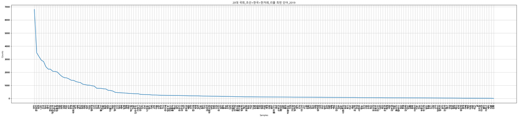

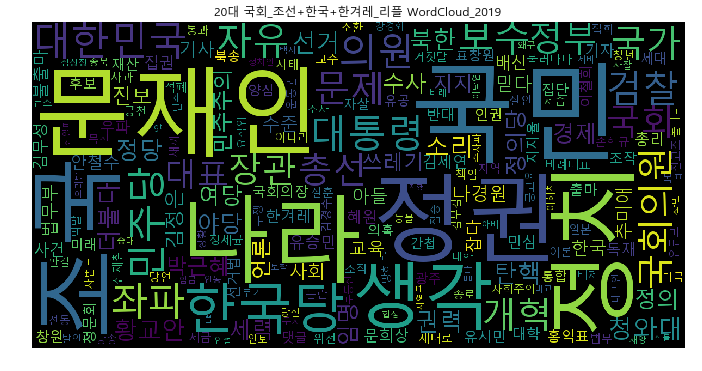

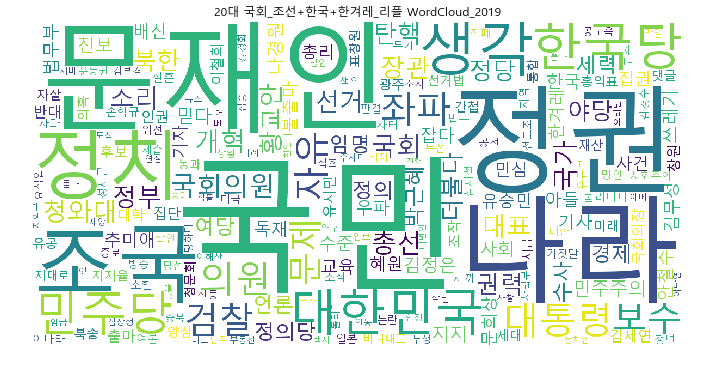

```python
this_month = '2019'
title_lc = '20대 국회_조선+한국+한겨레_리플 최빈 단어_'+this_month
title_wc = '20대 국회_조선+한국+한겨레_리플 WordCloud_'+this_month
fig_name_lc = '../KBS시사/시각화그림/20대 국회_라인_'+this_month
fig_name_wwc = '../KBS시사/시각화그림/20대 국회_워드클라우드w_'+this_month
fig_name_bwc = '../KBS시사/시각화그림/20대 국회_워드클라우드b_'+this_month


file_name = '../KBS시사/DaumPoli/new_freq/20대국회_2019_new.xlsx'
freq_df = pd.read_excel(file_name)
# 제거해줄 단어 필터링
print('최빈단어 수: ',len(freq_df))
# 전체적으로 반영될 del_words + 해당 기간에만 반영할 추가 del_words
current_del_words = del_words.copy()
More_del_words = ['없이']
current_del_words.extend(More_del_words)
print('필터링 대상 단어 수: ',len(current_del_words))

del_index = [i for i in range(len(freq_df)) if freq_df['words'][i] in current_del_words]
freq_df.drop(del_index, inplace = True)
freq_df.reset_index(inplace = True, drop = True)
print(' 필터링 된 최빈단어 수: ',len(freq_df))

# 라인차트에 넣을 단어 corpus 형태로 복원!!
corpus = []
for i in range(len(freq_df)):
    corpus.extend([str(freq_df['words'][i])]*freq_df['freq'][i])
whole_tokens_text = nltk.Text(corpus)

#     # 워드클라우드에 넣어줄 인스턴스
#     count_list = freq_df.values.tolist()
#     freq_dict = dict(count_list)

### 라인 차트에서는 최빈출 : 50개만!
matplotlib.rcParams.update({'font.size': 10,'font.weight' : 'bold'})
pylab.show = lambda: pylab.savefig(fig_name_lc+'.png',dpi=500)
plt.figure(figsize=(40,8))
plt.title(title_lc)
whole_tokens_text.plot()
plt.show()


### 빈도 워드클라우드!
# 워드클라우드는 200개 단어로 수행!
wordcloud = WordCloud(
    font_path="c:/Windows/Fonts/malgun.ttf",
    relative_scaling = 0.2,
    #background_color = 'white',
    width = 1200, height = 600
).generate_from_frequencies(dict(whole_tokens_text.vocab().most_common(200)))

plt.figure(figsize=(12,6))
plt.title(title_wc)
plt.imshow(wordcloud)
plt.axis("off")
pyplot.savefig(fig_name_bwc+'.png', dpi=400)
plt.show()

wordcloud = WordCloud(
    font_path="c:/Windows/Fonts/malgun.ttf",
    relative_scaling = 0.2,
    background_color = 'white',
    width = 1200, height = 600
).generate_from_frequencies(dict(whole_tokens_text.vocab().most_common(200)))

plt.figure(figsize=(12,6))
plt.title(title_wc)
plt.imshow(wordcloud)
plt.axis("off")
pyplot.savefig(fig_name_wc+'.png', dpi=400)
plt.show()
```

#### 20대 국회 2019_4월 빈도 분석 분류

```
최빈단어 수:  81
필터링 대상 단어 수:  96
 필터링 된 최빈단어 수:  57
```

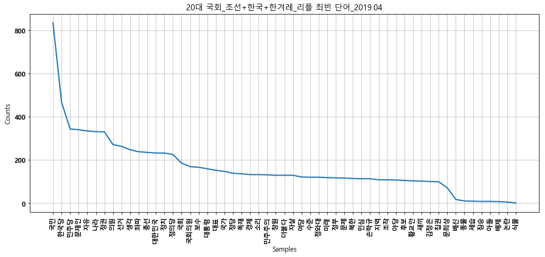

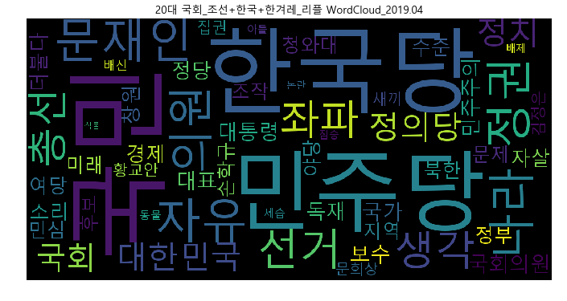

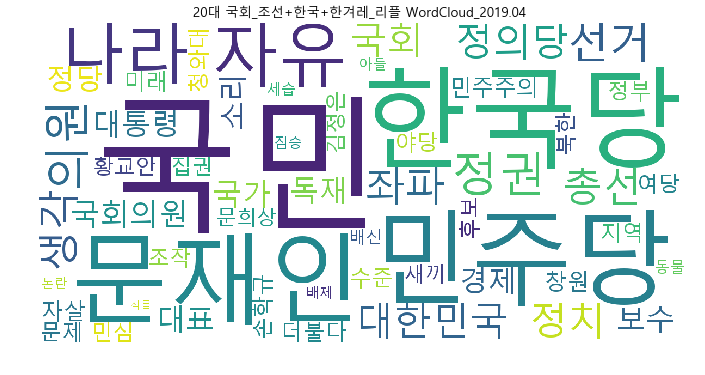

```python
this_month = '2019.04'
title_lc = '20대 국회_조선+한국+한겨레_리플 최빈 단어_'+this_month
title_wc = '20대 국회_조선+한국+한겨레_리플 WordCloud_'+this_month
fig_name_lc = '../KBS시사/시각화그림/20대 국회_라인_'+this_month
fig_name_wwc = '../KBS시사/시각화그림/20대 국회_워드클라우드w_'+this_month
fig_name_bwc = '../KBS시사/시각화그림/20대 국회_워드클라우드b_'+this_month


file_name = '../KBS시사/DaumPoli/new_freq/20대_freq70_2019.04.xlsx'
freq_df = pd.read_excel(file_name)
# 제거해줄 단어 필터링
print('최빈단어 수: ',len(freq_df))
# 전체적으로 반영될 del_words + 해당 기간에만 반영할 추가 del_words
current_del_words = del_words.copy()
More_del_words = ['없이']
current_del_words.extend(More_del_words)
print('필터링 대상 단어 수: ',len(current_del_words))

del_index = [i for i in range(len(freq_df)) if freq_df['words'][i] in current_del_words]
freq_df.drop(del_index, inplace = True)
freq_df.reset_index(inplace = True, drop = True)
print(' 필터링 된 최빈단어 수: ',len(freq_df))

# 라인차트에 넣을 단어 corpus 형태로 복원!!
corpus = []
for i in range(len(freq_df)):
    corpus.extend([str(freq_df['words'][i])]*freq_df['freq'][i])
whole_tokens_text = nltk.Text(corpus)

#     # 워드클라우드에 넣어줄 인스턴스
#     count_list = freq_df.values.tolist()
#     freq_dict = dict(count_list)

### 라인 차트에서는 최빈출 : 50개만!
matplotlib.rcParams.update({'font.size': 11,'font.weight' : 'bold'})
pylab.show = lambda: pylab.savefig(fig_name_lc+'.png',dpi=400)
plt.figure(figsize=(15,6))
plt.title(title_lc)
whole_tokens_text.plot()
plt.show()


### 빈도 워드클라우드!
# 워드클라우드는 200개 단어로 수행!
wordcloud = WordCloud(
    font_path="c:/Windows/Fonts/malgun.ttf",
    relative_scaling = 0.2,
    #background_color = 'white',
    width = 1200, height = 600
).generate_from_frequencies(dict(whole_tokens_text.vocab().most_common(200)))

plt.figure(figsize=(12,6))
plt.title(title_wc)
plt.imshow(wordcloud)
plt.axis("off")
pyplot.savefig(fig_name_bwc+'.png', dpi=400)
plt.show()

wordcloud = WordCloud(
    font_path="c:/Windows/Fonts/malgun.ttf",
    relative_scaling = 0.2,
    background_color = 'white',
    width = 1200, height = 600
).generate_from_frequencies(dict(whole_tokens_text.vocab().most_common(200)))

plt.figure(figsize=(12,6))
plt.title(title_wc)
plt.imshow(wordcloud)
plt.axis("off")
pyplot.savefig(fig_name_wc+'.png', dpi=400)
plt.show()
```

#### 20대 국회 2019.12월 빈도 분석 분류

```
최빈단어 수:  81
필터링 대상 단어 수:  96
 필터링 된 최빈단어 수:  57
```

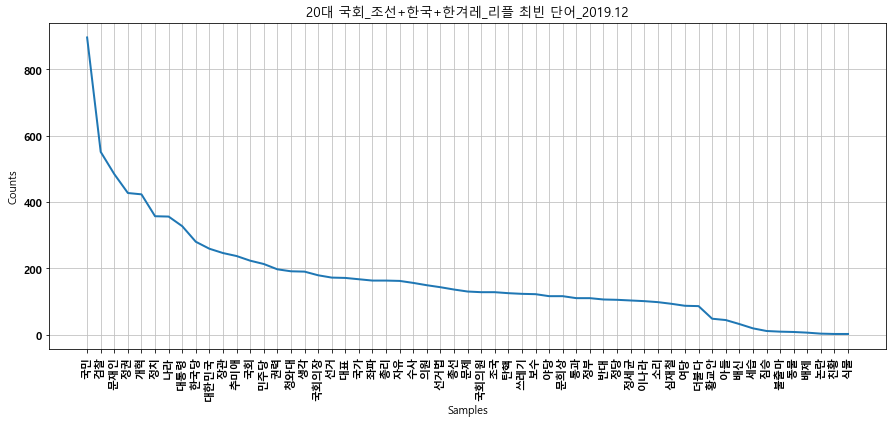

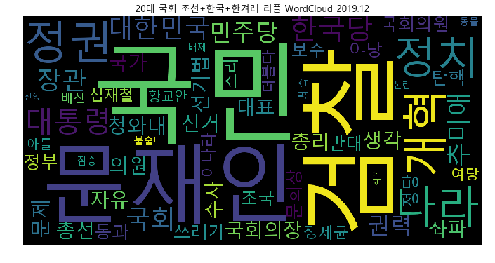

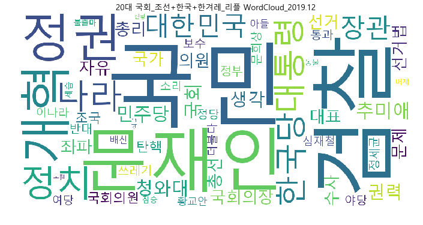

```python
this_month = '2019.12'
title_lc = '20대 국회_조선+한국+한겨레_리플 최빈 단어_'+this_month
title_wc = '20대 국회_조선+한국+한겨레_리플 WordCloud_'+this_month
fig_name_lc = '../KBS시사/시각화그림/20대 국회_라인_'+this_month
fig_name_wwc = '../KBS시사/시각화그림/20대 국회_워드클라우드w_'+this_month
fig_name_bwc = '../KBS시사/시각화그림/20대 국회_워드클라우드b_'+this_month


file_name = '../KBS시사/DaumPoli/new_freq/20대_freq70_2019.12.xlsx'
freq_df = pd.read_excel(file_name)
# 제거해줄 단어 필터링
print('최빈단어 수: ',len(freq_df))
# 전체적으로 반영될 del_words + 해당 기간에만 반영할 추가 del_words
current_del_words = del_words.copy()
More_del_words = ['없이']
current_del_words.extend(More_del_words)
print('필터링 대상 단어 수: ',len(current_del_words))

del_index = [i for i in range(len(freq_df)) if freq_df['words'][i] in current_del_words]
freq_df.drop(del_index, inplace = True)
freq_df.reset_index(inplace = True, drop = True)
print(' 필터링 된 최빈단어 수: ',len(freq_df))

# 라인차트에 넣을 단어 corpus 형태로 복원!!
corpus = []
for i in range(len(freq_df)):
    corpus.extend([str(freq_df['words'][i])]*freq_df['freq'][i])
whole_tokens_text = nltk.Text(corpus)

#     # 워드클라우드에 넣어줄 인스턴스
#     count_list = freq_df.values.tolist()
#     freq_dict = dict(count_list)

### 라인 차트에서는 최빈출 : 50개만!
matplotlib.rcParams.update({'font.size': 11,'font.weight' : 'bold'})
pylab.show = lambda: pylab.savefig(fig_name_lc+'.png',dpi=400)
plt.figure(figsize=(15,6))
plt.title(title_lc)
whole_tokens_text.plot()
plt.show()


### 빈도 워드클라우드!
# 워드클라우드는 200개 단어로 수행!
wordcloud = WordCloud(
    font_path="c:/Windows/Fonts/malgun.ttf",
    relative_scaling = 0.2,
    #background_color = 'white',
    width = 1200, height = 600
).generate_from_frequencies(dict(whole_tokens_text.vocab().most_common(200)))

plt.figure(figsize=(12,6))
plt.title(title_wc)
plt.imshow(wordcloud)
plt.axis("off")
pyplot.savefig(fig_name_bwc+'.png', dpi=400)
plt.show()

wordcloud = WordCloud(
    font_path="c:/Windows/Fonts/malgun.ttf",
    relative_scaling = 0.2,
    background_color = 'white',
    width = 1200, height = 600
).generate_from_frequencies(dict(whole_tokens_text.vocab().most_common(200)))

plt.figure(figsize=(12,6))
plt.title(title_wc)
plt.imshow(wordcloud)
plt.axis("off")
pyplot.savefig(fig_name_wc+'.png', dpi=400)
plt.show()
```